### [Back](http://falconer94.github.io/)

# **Underlying conditions and symptoms of COVID-19 in the US**

## Relationship between COVID-19, pneumonia, and Influenza

### Tidy 1

After loading the libraries and data, I tidied them up. They were pretty messy.

```r
cv <- cv %>%
  rename("Date.as.of" = "ï..Data.as.of") %>%
  rename("All.cv.deaths" = "All.COVID.19.Deaths..U07.1.") %>%
  rename("All.pna.deaths" = "All.Pneumonia.Deaths..J12.0.J18.9.") %>%
  rename("Pna.cv.deaths"  = "Deaths.with.Pneumonia.and.COVID.19..J12.0.J18.9.and.U07.1.") %>%
  rename("All.flu.deaths" = "All.Influenza.Deaths..J09.J11.") %>%
  rename("pna.flu.cv.deaths" = "Pneumonia..Influenza..and.COVID.19.Deaths")


# Rename age classes
cv$Indicator <- str_replace(cv$Indicator, "â€“","-") %>%
  str_remove("years") %>% str_remove(" year")

# by_age; remove unused columns
by_age <-
  cv %>% filter(Group == "By age") %>%
  select(Indicator,All.cv.deaths,All.pna.deaths,All.flu.deaths,Pna.cv.deaths,)

# Remove commas; change to numeric
by_age$All.cv.deaths <- as.numeric(gsub(",","",by_age$All.cv.deaths))
by_age$All.pna.deaths <- as.numeric(gsub(",","",by_age$All.pna.deaths))
by_age$Pna.cv.deaths <- as.numeric(gsub(",","",by_age$Pna.cv.deaths))
by_age$All.flu.deaths <- as.numeric(gsub(",","",by_age$All.flu.deaths))

# Indicator as facter; reorder levels so the "Under 1" is not last
by_age$Indicator <-
  factor(by_age$Indicator,levels = c("Under 1","1-4 ","5-14 ","15-24 ","25-34 ","35-44 ","45-54 ","55-64 ","65-74 ","75-84 ","85  and over", "All ages"))

# Remove All ages
by_age <-
  by_age %>% filter(Indicator != "All ages")

# Gather columns as variable
by_age <-
  gather(by_age, -"Indicator", key = "type",value = "deaths")

# Type as factor
by_age$type <-
  as.factor(by_age$type)
```

### Plot 1

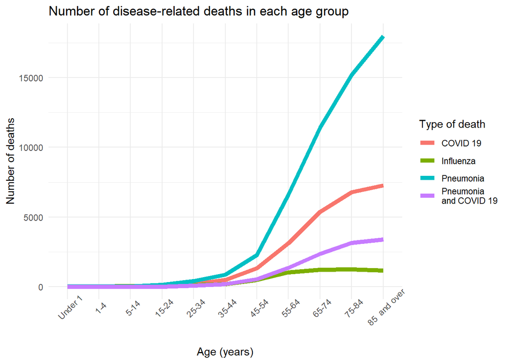

Data souce: https://www.cdc.gov/nchs/nvss/vsrr/covid19/  
The number of deaths per age group in the US. The likelihood of dying from these diseases is greater in older people, particularly pneumonia. There seems to be a correlation between pneumonia and COVID-19 as well.

```r
# spread
by_age_spread <-
  spread(by_age,key = "type",value = "deaths")
cor.test(by_age_spread$All.cv.deaths,by_age_spread$All.pna.deaths)
```

```
##
##  Pearson's product-moment correlation
##
## data:  by_age_spread$All.cv.deaths and by_age_spread$All.pna.deaths
## t = 34.896, df = 9, p-value = 6.439e-11
## alternative hypothesis: true correlation is not equal to 0
## 95 percent confidence interval:
##  0.9853860 0.9990796
## sample estimates:
##       cor
## 0.9963249
```

The p-value of COVID-19 and pneumonia deaths is small and the correlation value is high, suggesting that there is a strong correlation.

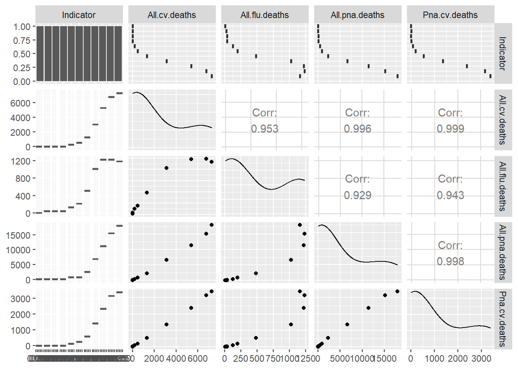

```r
ggpairs(by_age_spread)
```

ggpairs shows that the correlation values are very high, so there are very strong correlations between all three diseases.  
# Underlying conditions and symptoms  
This next data set shows the proportions of underlying conditions and symptoms of hospitalized COVID-19 infected patients by age group.

```r
# Let's tidy up this mess!

# Underlying conditions
uc <- read.csv("Underlying_conditions_by_age_group.csv") %>%
  rename("Underlying.condition" = "ï..Underlying.condition") %>%
  rename("19-49" = "X18â..49") %>%
  rename("50-64" = "X50â..64") %>%
  rename("65 and over" = "â..65")

# Symptoms
sm <- read.csv("Symptoms_by_age_group.csv") %>%
  rename("Symptoms" = "ï..Symptoms") %>%
  rename("19-49" = "X18â..49") %>%
  rename("50-64" = "X50â..64") %>%
  rename("65 and over" = "â..65.years")


# Extract only the proportion values that are within parentheses; as numeric
uc$Overall <-
  str_sub(uc$Overall, -5,-2) %>% str_remove("\\(") %>% as.numeric()
uc$`19-49` <-
  str_sub(uc$`19-49`, -5,-2) %>% str_remove("\\(") %>% as.numeric()
uc$`50-64` <-
  str_sub(uc$`50-64`, -5,-2) %>% str_remove("\\(") %>% as.numeric()
uc$`65 and over` <-
  str_sub(uc$`65 and over`, -5,-2) %>% str_remove("\\(") %>% as.numeric()

sm$Overall <-
  str_sub(sm$Overall, -5,-2) %>% str_remove("\\(") %>% as.numeric()
sm$`19-49` <-
  str_sub(sm$`19-49`, -5,-2) %>% str_remove("\\(") %>% as.numeric()
sm$`50-64` <-
  str_sub(sm$`50-64`, -5,-2) %>% str_remove("\\(") %>% as.numeric()
sm$`65 and over` <-
  str_sub(sm$`65 and over`, -5,-2) %>% str_remove("\\(") %>% as.numeric()

# Gather age groups
uc <- uc %>%
  gather("Overall","19-49","50-64","65 and over", key="age.group", value = "percentage")

sm <- sm %>%
  gather("Overall","19-49","50-64","65 and over", key="age.group", value = "percentage")

# Remove "Overall"
uc <-
  uc %>% filter(age.group != "Overall")
sm <-
  sm %>% filter(age.group != "Overall")

# Rename symptoms/conditions
uc$Underlying.condition <- str_remove_all(uc$Underlying.condition,"Â") %>% str_remove_all("Â¶") %>%
  str_trim() %>% str_remove_all("¶")

sm$Symptoms <- str_remove_all(sm$Symptoms,"Â") %>% str_remove_all("Â¶") %>%
  str_trim() %>% str_remove_all("¶")

# age group as factor
uc$age.group <- as.factor(uc$age.group)
sm$age.group <- as.factor(sm$age.group)
```

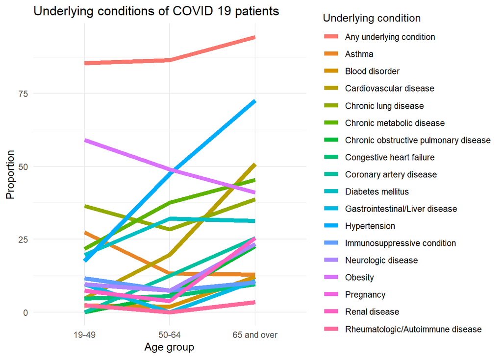

A large proportion of patients had any of these kinds of conditions along with COVID-19. This suggests that those who are 65 and older are more likely to contract the disease. In terms of the underlying conditions, those with hypertension, obesity, or cardiovascular related conditions are higher at risk.

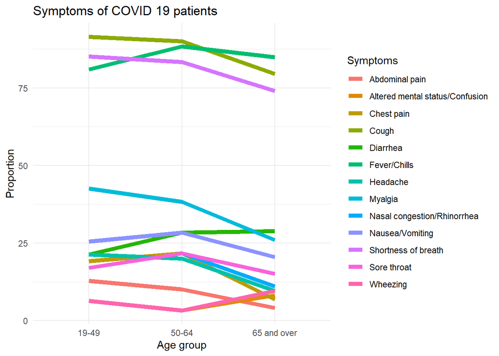

Data source: “Table” from https://www.cdc.gov/mmwr/volumes/69/wr/mm6915e3.htm  
Those infected with COVID-19 are most likely to experience fever/chills, shortness of breath, and coughing, regardless of the age.  
## Conclusion  
COVID-19 is strongly correlated with preexisting respiratory and cardiovascular conditions.